# Annotate NC clusters (SoupX filtered)

Zhiyuan Hu

2022-12-27 (last modified: 2022-12-29)

# Read data

```r
seu <- readRDS("/t1-data/project/tsslab/zhu/multiome/analysis_newref/clustering/rds/seuobj_rna/seu_RNAsoupx_NC.rds")
DefaultAssay(seu) <- "RNA"
nc.markers <- read.csv("/t1-data/project/tsslab/zhu/multiome/analysis_newref/clustering/results/NC_markers_RNAsoupx.csv")
```

# add Genotyping prediction results

This step is done by the genotype.sh (amplicon_analysis.R) in the genotyping directory

```r
pred <- readRDS("/t1-data/project/tsslab/zhu/multiome/analysis_newref/genotyping/rds/predicted_genotype.rds")
table(is.na(pred$predicted_genotype))
```

```
##
## FALSE  TRUE
##   943 15607
```

```r
table(rownames(pred) %in% colnames(seu)) # how many cells have prediction
```

```
##
##  TRUE
## 16550
```

```r
pred <- pred[!is.na(pred$predicted_genotype),,drop = F]
seu$genotype_new <- seu$genotype
seu$genotype_new[match(rownames(pred), colnames(seu))] <- pred$predicted_genotype
table(seu$genotype_new, seu$sample) # genotype (ground truth + predicted)
```

```
##
##       10cit 10dp 16cit 16dp 22cit 22cit2 22dp 4mix
##   cit  3385    0  1833    0  4709     69    0  608
##   dp      0 1681     0  812     0      0 3118  335
```

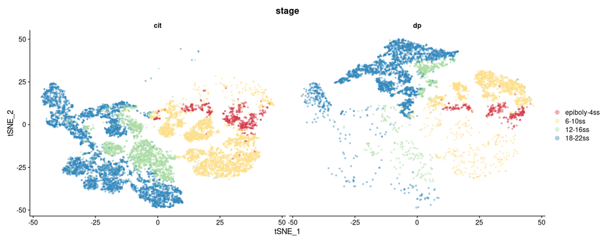

```r
DimPlot(seu, reduction = "tsne", split.by = "genotype_new",
        cols = alpha(stage_cols[c(2,5,8,10)], 0.4), pt.size = 1, group.by = "stage")
```

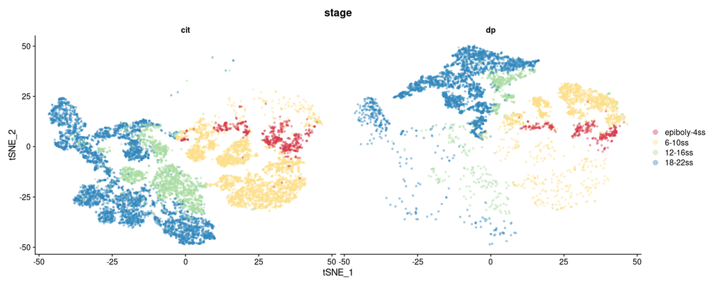

```r
DimPlot(seu, reduction = "tsne", split.by = "genotype_new",
        cols = alpha(stage_cols[c(2,5,8,10)], 0.4), pt.size = 1, group.by = "stage")
```

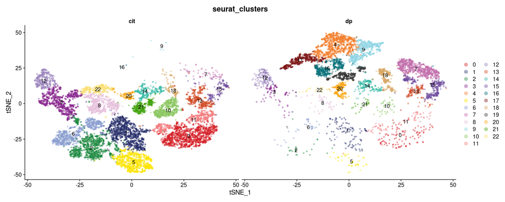

```r
DimPlot(seu, reduction = "tsne", split.by = "genotype_new",
        cols = alpha(col.ls, 0.4), pt.size = 1, group.by = "seurat_clusters", label = TRUE)
```

### Genotype-specific clusters

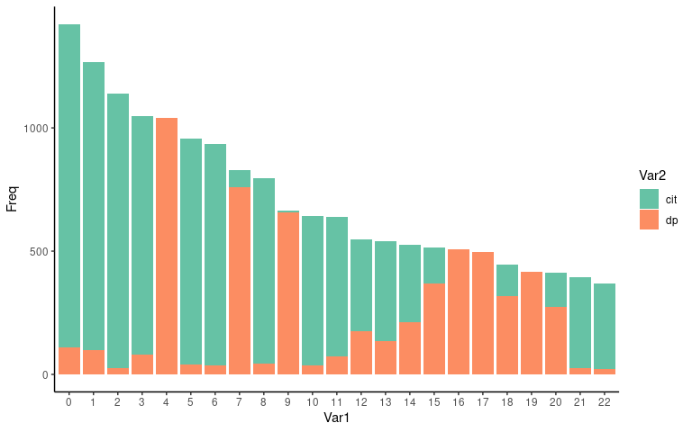

```r
df <- data.frame(table(seu$seurat_clusters, seu$genotype_new))
df$Var2 <- factor(df$Var2, levels = c("cit","dp"))
ggplot(df, aes(x = Var1, y = Freq, fill = Var2)) + geom_bar(position = "stack", stat = "identity") + scale_fill_manual(values = alpha(genotype_cols)[c(1,2)]) + theme_classic()
```

# Marker genes

```r
nc.markers %>% group_by(cluster) %>% top_n(n = 2, wt = avg_log2FC) -> top2
top2
```

```
## # A tibble: 46 × 8
## # Groups:   cluster [23]
##    X                    p_val avg_log2FC pct.1 pct.2 p_val_adj cluster gene
##    <chr>                <dbl>      <dbl> <dbl> <dbl>     <dbl>   <int> <chr>
##  1 kcnab1a          0               2.26 0.975 0.389 0               0 kcnab1a
##  2 snai1b           0               2.04 0.935 0.422 0               0 snai1b
##  3 si:dkey-22o22.21 0               1.52 0.718 0.238 0               1 si:dkey-…
##  4 plpp3            3.12e-292       1.51 0.878 0.466 8.62e-288       1 plpp3
##  5 grem2b           0               2.20 0.694 0.104 0               2 grem2b
##  6 pmp22a1          0               1.54 0.951 0.575 0               2 pmp22a
##  7 slc45a2          0               2.76 0.79  0.06  0               3 slc45a2
##  8 pmela            0               2.46 0.638 0.113 0               3 pmela
##  9 alx4a1           0               2.23 0.896 0.264 0               4 alx4a
## 10 dacha            0               2.04 0.86  0.366 0               4 dacha
## # … with 36 more rows
```

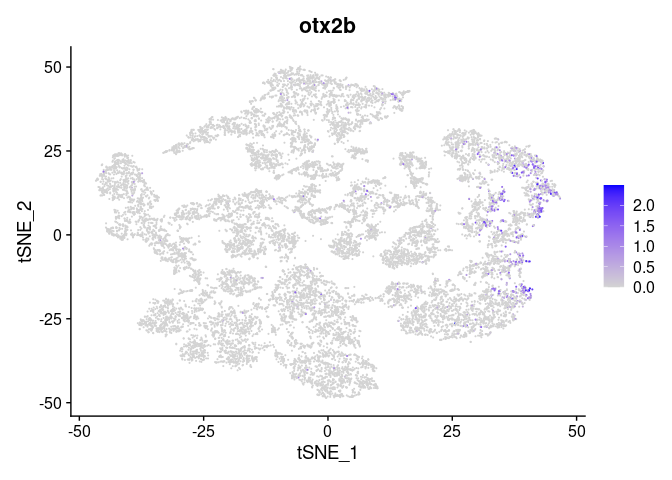

```r
FeaturePlot(seu, features = c("otx2b"), reduction  = 'tsne')
```

# Cell cycle

```r
# A list of cell cycle markers, from Tirosh et al, 2015, is loaded with Seurat.  We can
# segregate this list into markers of G2/M phase and markers of S phase
s.genes <- tolower(cc.genes$s.genes)
g2m.genes <- tolower(cc.genes$g2m.genes)

seu <- CellCycleScoring(seu, s.features = s.genes, g2m.features = g2m.genes, set.ident = TRUE)
```

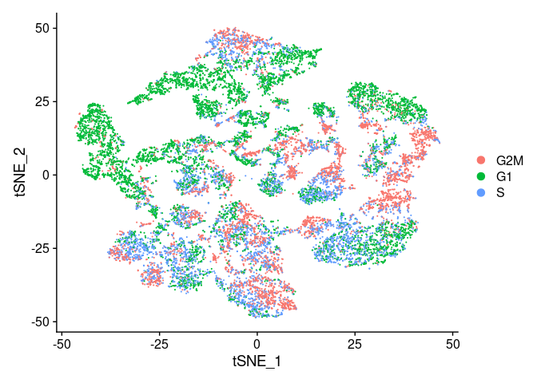

```r
DimPlot(seu,  reduction  = 'tsne')
```

# Annotation

```r
# Make a set of data.frames to keep track during cluster assignment.
clusters <- length(unique(seu$seurat_clusters))
cluster.assignments <- data.frame(
  cluster=(1:clusters)-1,
  name=rep(NA, clusters),
  row.names=(1:clusters)-1
)

cluster.assignments["13","name"] <- "NPB_nohox"
cluster.assignments["15","name"] <- "NPB_nohox_cycling"
cluster.assignments["18","name"] <- "NPB_hox2" #??
cluster.assignments["14","name"] <- "NPB_hox3" #??

cluster.assignments["11","name"] <- "dNC_nohox_cycling" # delaminating NC
cluster.assignments["0","name"] <- "dNC_nohox"
cluster.assignments["10","name"] <- "dNC_hoxa2b"
cluster.assignments["21","name"] <- "dNC_hox34"
cluster.assignments["20","name"] <- "NC_trunk"

cluster.assignments["22","name"] <- "mNC_vagal"
cluster.assignments["8","name"] <- "mNC_hox34"

cluster.assignments["1","name"] <- "mNC_nohox" # migratory NC
cluster.assignments["2","name"] <- "mNC_arch1"
cluster.assignments["6","name"] <- "mNC_arch2"
cluster.assignments["5","name"] <- "mNC_head_mesenchymal"

cluster.assignments["3","name"] <- "Pigment_sox6_high"
cluster.assignments["12","name"] <- "Pigment_gch2_high"

cluster.assignments["7","name"] <- "Mutant_nohox_early"
cluster.assignments["4","name"] <- "Mutant_nohox_cycling"
cluster.assignments["9","name"] <- "Mutant_nohox_12_22ss"
cluster.assignments["16","name"] <- "Mutant_hox2" ##?
cluster.assignments["19","name"] <- "Mutant_hox3" ##?
cluster.assignments["17","name"] <- "Mutant_pigment"
```

# Add annotation

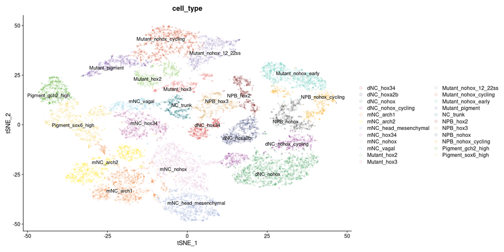

```r
seu$cell_type <- NA
seu$cell_type <- cluster.assignments$name[match(seu$seurat_clusters, cluster.assignments$cluster)]
# seu$cell_type <- paste0(seu$seurat_clusters, ":", seu$cell_type)
# seu$cell_type <- factor(seu$cell_type, paste0(cluster.assignments$cluster, ":", cluster.assignments$name))
#
col.ls2 <- col.ls
# names(col.ls2) <- paste0(cluster.assignments$cluster, ":", cluster.assignments$name)
DimPlot(seu, label = T, group.by = "cell_type",
        reduction = "tsne", cols = alpha(col.ls2, 0.1), pt.size = 1,
        repel = T)
```

## other markers: BMP11/gdf1

gdf11: cardiac and skeletal muscle https://www.ncbi.nlm.nih.gov/pmc/articles/PMC5833306/

gdf11 is bmp11: https://www.oncotarget.com/article/20258/text/; https://www.ncbi.nlm.nih.gov/pmc/articles/PMC3773925/

cadm1a: Predicted to be active in neuron projection; plasma membrane; and synapse

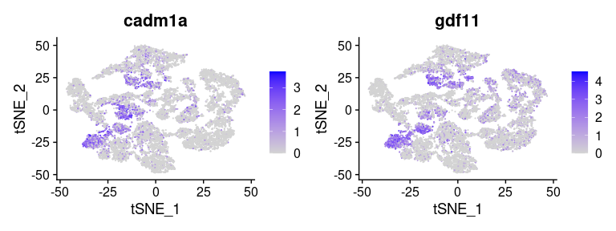

```r
FeaturePlot(seu, features = c("cadm1a","gdf11"), pt.size = 0.1, reduction = "tsne")
```

ebf3a: sensory system

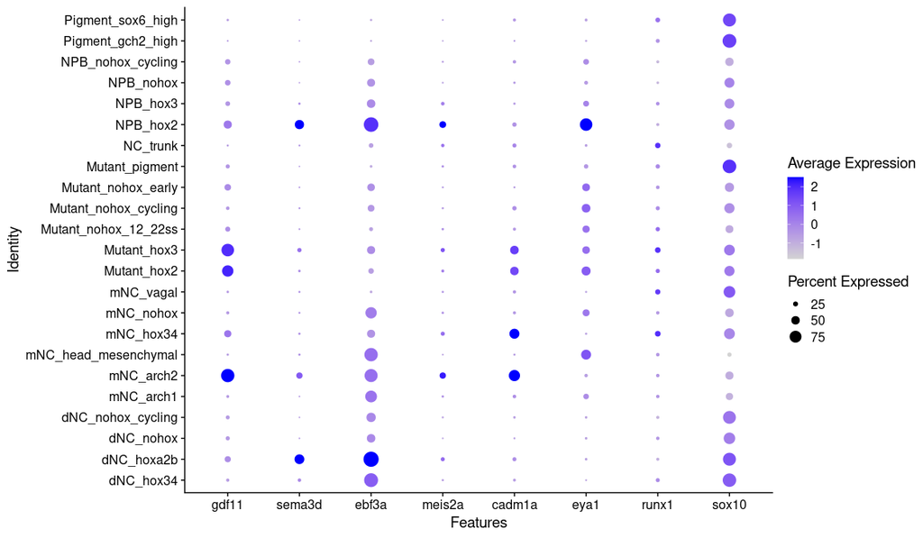

```r
DotPlot(seu, features = c("gdf11","sema3d","ebf3a","meis2a","cadm1a","eya1","runx1","sox10"), group.by = "cell_type")
```

## hox genes

[1] "hoxa13b" "hoxa11b" "hoxa10b" "hoxa9b" "hoxa2b" "hoxa13a" "hoxa11a" "hoxa9a" "hoxa4a" "hoxa5a" "hoxa1a" [1] "hoxb13a" "hoxb10a" "hoxb9a" "hoxb8a" "hoxb7a" "hoxb3a" "hoxb6a" "hoxb5a" "hoxb4a" "hoxb2a" "hoxb1a" "hoxb8b" "hoxb6b" "hoxb5b" "hoxb1b" [1] "hoxc10a" "hoxc13a" "hoxc12a" "hoxc11a" "hoxc3a" "hoxc9a" "hoxc8a" "hoxc6a" "hoxc5a" "hoxc4a" "hoxc1a" "hoxc13b" "hoxc12b" "hoxc11b" "hoxc6b" [1] "hoxd3a" "hoxd4a" "hoxd9a" "hoxd10a" "hoxd11a" "hoxd12a" "hoxd13a"

mafba/Kreisler: r5 r6 Follistatin/fsta: r2, r4, r6 Krox-20/egr2: r3 r5 Engrailed-2/en2b en2a: midbrain, r1 CRABP/ :r4 r5 r6

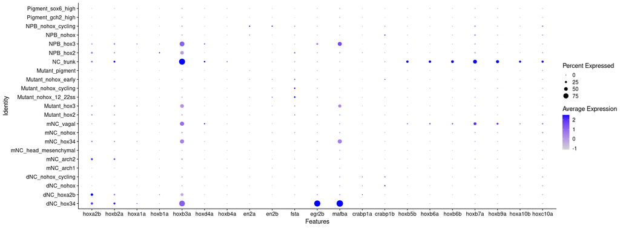

```r
# hox_genes <-  unique(nc.markers$gene[grep("hox", nc.markers$gene)])
# hox_genes <- stringr::str_sort(hox_genes, numeric = T )
# hox_genes[order(hox_genes, decreasing = FALSE)]
hox_genes <- c("hoxa2b","hoxb2a",
               "hoxa1a","hoxb1a",
               "hoxb3a",
               "hoxd4a", "hoxb4a",
               "en2a","en2b",
               "fsta","egr2b", "mafba",
               "crabp1a","crabp1b","hoxb5b","hoxb6a","hoxb6b",
              "hoxb7a","hoxb9a","hoxa10b","hoxc10a"
               )
DotPlot(seu, features = c(hox_genes), group.by = "cell_type")
```

## Vagal markers

itga3 is a heart marker ? https://etheses.whiterose.ac.uk/27656/1/DERRICK_Thesis_Aug2020.pdf

runx2b is a osteoblast lineage marker https://www.nature.com/articles/s41467-021-27594-w

cxcl12a stromal branch

hyal4 cartilage, bone, periosteum, and tendon and ligament

fgf10a/b+ branch connected to gill pillar, tunica media, and perivascular cells, as well as a distinct type of gill cartilage

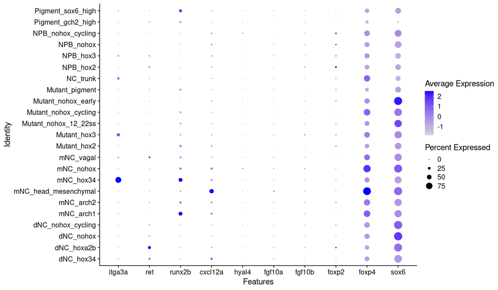

```r
DotPlot(seu, features = c("itga3a","ret","runx2b","cxcl12a","hyal4","fgf10a","fgf10b","foxp2","foxp4","sox6"), group.by = "cell_type")
```

## neural fate genes

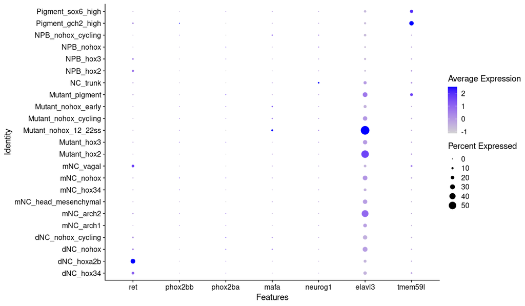

```r
DotPlot(seu, features = c("ret","phox2bb","phox2ba","mafa","neurog1","neurog2","elavl3","tmem59l"), group.by = "cell_type")
```

## Head mesenchymal markers

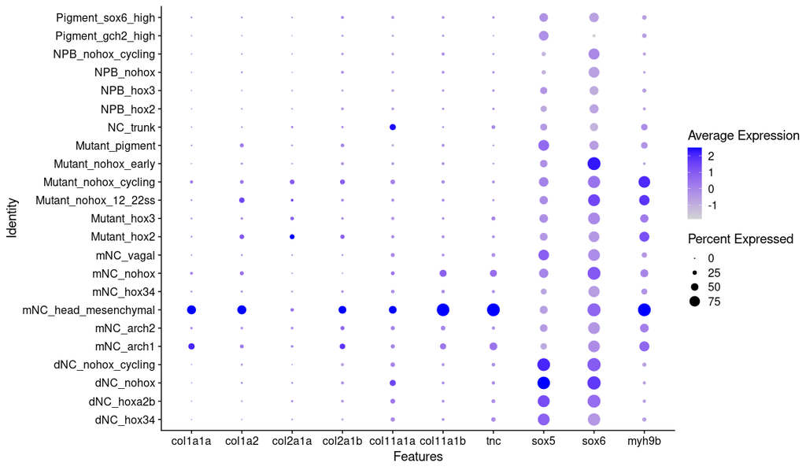

```r
DotPlot(seu, features = c("col1a1a","col1a2","col2a1a", "col2a1b","col11a1a","col11a1b", "tnc","sox5","sox6","myh9b"), group.by = "cell_type")
```

## migrating NC markers

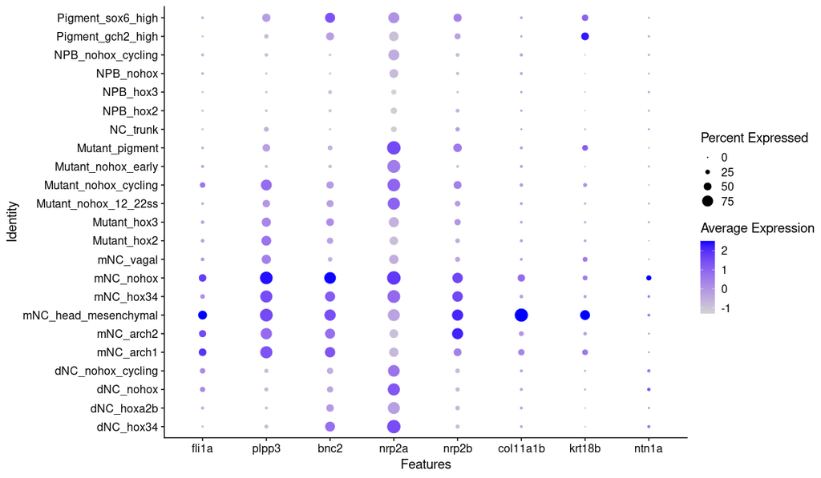

```r
DotPlot(seu, features = c("fli1a","plpp3","bnc2","nrp2a","nrp2b","col11a1b","krt18b","ntn1a"), group.by = "cell_type")
```

# Save data

```r
saveRDS(seu@meta.data,"/t1-data/project/tsslab/zhu/multiome/analysis_newref/clustering/rds/metadata/seu_RNAsoupx_NC_metadata.rds")
```